# **Assignment 1**

This assignment covers some basics of graph theory and traditonal graph analysis approaches with **NetworkX** package, including the implementation of defining undirected and directed graphs, homogeneous graph vs. heterogenous graph, comppute their adjacency matrix- $A$, degree matrix - $D$, and laplacian matrix - $L$.

The primary objective of this assignment is to deepen your understanding of traditional graph analysis methods (e.g., node level statistics and graph kenel methods for measuring graph similarity) and basic graph operations using **NetworkX and Grakel package**. Additionally, you will become more acquainted with implementing graph analytics using python, specifically for the task of graph similarity comparisons.

**Reference:**

- Tutorial on the NetworkX library: https://networkx.org/documentation/stable/tutorial.html
- Grakel package for graph kenel implementations: https://ysig.github.io/GraKeL/0.1a8/graph_kernel.html

**Note:** You must run/evaluate all cells. **Order of cell execution is important.**

Other reference: https://chatgpt.com/share/68d7a2e5-7500-8013-a6b0-e732f2bdaa77

```python
import sys
print(sys.executable)
print(sys.version)
```

```
/usr/bin/python3
3.12.11 (main, Jun  4 2025, 08:56:18) [GCC 11.4.0]
```

## **1. Basic graph definition and matrix representation (11pts)**

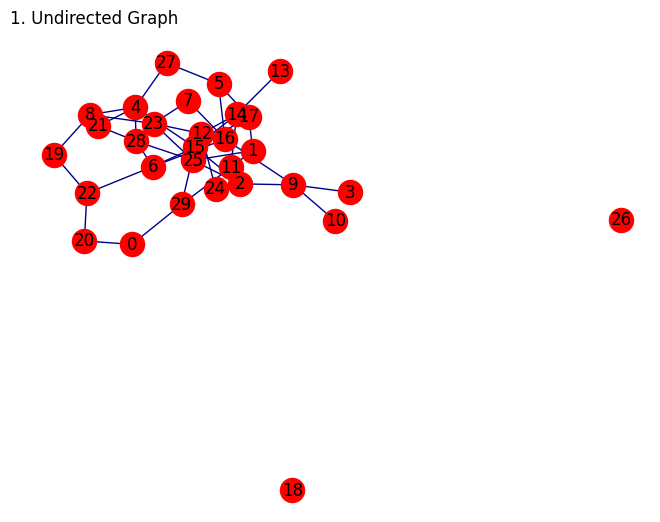

```
Adjacency Matrix for undirected graph:
 [[0 0 0 0 0 0 0 0 0 0 0 0 0 0 0 0 0 0 0 0 1 0 0 0 0 0 0 0 0 1]
 [0 0 0 0 0 0 0 0 0 0 0 1 0 0 0 0 0 1 0 0 0 0 0 0 0 1 0 0 0 0]
 [0 0 0 0 0 0 0 0 0 1 0 0 0 0 0 1 0 0 0 0 0 0 0 0 1 1 0 0 0 0]
 [0 0 0 0 0 0 0 0 0 1 0 0 0 0 0 0 0 0 0 0 0 0 0 0 0 0 0 0 0 0]
 [0 0 0 0 0 0 0 0 1 0 0 0 0 0 0 1 0 0 0 0 0 1 0 0 0 0 0 1 1 0]
 [0 0 0 0 0 0 0 0 0 0 0 0 0 0 0 0 1 1 0 0 0 0 0 0 0 0 0 1 0 0]
 [0 0 0 0 0 0 0 0 0 0 0 0 0 0 0 1 1 0 0 0 0 0 1 0 0 0 0 0 1 0]
 [0 0 0 0 0 0 0 0 0 0 0 0 0 0 0 0 1 0 0 0 0 0 0 1 0 0 0 0 0 0]
 [0 0 0 0 1 0 0 0 0 0 0 0 0 0 0 0 0 0 0 1 0 0 0 1 0 0 0 0 0 0]
 [0 0 1 1 0 0 0 0 0 0 1 0 0 0 0 0 1 0 0 0 0 0 0 0 0 0 0 0 0 0]
 [0 0 0 0 0 0 0 0 0 1 0 0 0 0 0 0 0 0 0 0 0 0 0 0 0 0 0 0 0 0]
 [0 1 0 0 0 0 0 0 0 0 0 0 0 0 1 0 0 0 0 0 0 0 0 0 0 0 0 0 0 1]
 [0 0 0 0 0 0 0 0 0 0 0 0 0 0 1 0 0 0 0 0 0 0 0 1 1 0 0 0 0 0]
 [0 0 0 0 0 0 0 0 0 0 0 0 0 0 1 0 0 0 0 0 0 0 0 0 0 0 0 0 0 0]
 [0 0 0 0 0 0 0 0 0 0 0 1 1 1 0 1 0 0 0 0 0 0 0 0 0 0 0 0 0 0]
 [0 0 1 0 1 0 1 0 0 0 0 0 0 0 1 0 0 1 0 0 0 0 0 0 0 0 0 0 0 1]
 [0 0 0 0 0 1 1 1 0 1 0 0 0 0 0 0 0 0 0 0 0 0 0 0 0 0 0 0 0 0]
 [0 1 0 0 0 1 0 0 0 0 0 0 0 0 0 1 0 0 0 0 0 0 0 0 0 0 0 0 0 0]
 [0 0 0 0 0 0 0 0 0 0 0 0 0 0 0 0 0 0 0 0 0 0 0 0 0 0 0 0 0 0]
 [0 0 0 0 0 0 0 0 1 0 0 0 0 0 0 0 0 0 0 0 0 0 1 0 0 0 0 0 0 0]
 [1 0 0 0 0 0 0 0 0 0 0 0 0 0 0 0 0 0 0 0 0 0 1 0 0 0 0 0 0 0]
 [0 0 0 0 1 0 0 0 0 0 0 0 0 0 0 0 0 0 0 0 0 0 0 0 0 0 0 0 1 0]
 [0 0 0 0 0 0 1 0 0 0 0 0 0 0 0 0 0 0 0 1 1 0 0 0 0 0 0 0 0 0]
 [0 0 0 0 0 0 0 1 1 0 0 0 1 0 0 0 0 0 0 0 0 0 0 0 0 1 0 0 1 0]
 [0 0 1 0 0 0 0 0 0 0 0 0 1 0 0 0 0 0 0 0 0 0 0 0 0 0 0 0 0 0]
 [0 1 1 0 0 0 0 0 0 0 0 0 0 0 0 0 0 0 0 0 0 0 0 1 0 0 0 0 1 0]
 [0 0 0 0 0 0 0 0 0 0 0 0 0 0 0 0 0 0 0 0 0 0 0 0 0 0 0 0 0 0]
 [0 0 0 0 1 1 0 0 0 0 0 0 0 0 0 0 0 0 0 0 0 0 0 0 0 0 0 0 0 0]
 [0 0 0 0 1 0 1 0 0 0 0 0 0 0 0 0 0 0 0 0 0 1 0 1 0 1 0 0 0 0]
 [1 0 0 0 0 0 0 0 0 0 0 1 0 0 0 1 0 0 0 0 0 0 0 0 0 0 0 0 0 0]]

Degree Matrix for undirected graph:
 [[2 0 0 0 0 0 0 0 0 0 0 0 0 0 0 0 0 0 0 0 0 0 0 0 0 0 0 0 0 0]
 [0 3 0 0 0 0 0 0 0 0 0 0 0 0 0 0 0 0 0 0 0 0 0 0 0 0 0 0 0 0]
 [0 0 4 0 0 0 0 0 0 0 0 0 0 0 0 0 0 0 0 0 0 0 0 0 0 0 0 0 0 0]
 [0 0 0 1 0 0 0 0 0 0 0 0 0 0 0 0 0 0 0 0 0 0 0 0 0 0 0 0 0 0]
 [0 0 0 0 5 0 0 0 0 0 0 0 0 0 0 0 0 0 0 0 0 0 0 0 0 0 0 0 0 0]
 [0 0 0 0 0 3 0 0 0 0 0 0 0 0 0 0 0 0 0 0 0 0 0 0 0 0 0 0 0 0]
 [0 0 0 0 0 0 4 0 0 0 0 0 0 0 0 0 0 0 0 0 0 0 0 0 0 0 0 0 0 0]
```

[output cut: 297 more lines]

```
   0  0  0  0  0 -1]
 [ 0  0  0  0  0  0  0  0  0  0  0  0  0 -1  0  0  0 -1  0  0  0  0  0 -1
   3  0  0  0  0  0]
 [ 0  0  0 -1  0  0  0  0  0  0  0  0  0  0  0  0  0  0  0  0  0  0  0  0
   0  1  0  0  0  0]
 [ 0  0  0  0  0  0  0 -1  0  0  0  0  0  0  0  0  0 -1  0  0  0  0  0  0
   0  0  2  0  0  0]
 [ 0 -1  0  0  0  0  0  0  0  0  0  0  0  0  0 -1 -1  0  0  0  0  0  0  0
   0  0  0  3  0  0]
 [ 0  0  0  0  0  0  0  0  0  0  0 -1  0  0  0  0  0 -1  0  0  0  0  0  0
   0  0  0  0  2  0]
 [ 0  0  0  0 -1  0  0 -1  0  0  0  0  0  0  0  0  0  0 -1  0  0  0  0  0
   0  0  0  0  0  3]]

 L_out is fine.
```

```python
import networkx as nx
import matplotlib.pyplot as plt
import random
import numpy as np

seed = 33

random.seed(seed)


####################################
'''1. Undirected Graph'''
####################################

# Define a random undirected graph ($G_u$) with 30 nodes (1pt)
# (Please make the graph reproducible via set a fixed random seed)
# Using the Erdos-Rényi model for undirected generation (each edge has probability p of being created)

n = 30   # number of nodes
p = 0.1  # probability of edge creation

G = nx.gnp_random_graph(n,p,seed=seed)

# Draw the graph (1pt)
nx.draw(G, with_labels=True, node_color='red', edge_color='darkblue')
plt.title('1. Undirected Graph', loc="left")
plt.show()
# Compute and visualize the A, D, and L matrices for G_u (3pts)
A = nx.adjacency_matrix(G)
print("\nAdjacency Matrix for undirected graph: \n",A.todense())

degrees = G.degree()
D = np.diag([degrees[node] for node in G.nodes()])
print("\nDegree Matrix for undirected graph: \n",D)

L = nx.laplacian_matrix(G)
print("\nLaplacian Matrix for undirected graph: \n", L.todense())

L1 = D - A
flag = 0
for i in range(L1.shape[0]):
  for j in range(L1.shape[1]):
    if L1[i,j] != L[i,j]:
      flag = 1

status = '\nLaplacians for undirected match.' if flag==0 else '\nThis cannot be happening.'
print(status)

####################################
'''2. Directed Graph'''
####################################

# Define a directed graph (G_d)  with 30 nodes  (1pt)
G_d = nx.gnp_random_graph(n,p,seed=seed,directed=True)


# Compute and visualize the A, D_in, D_out,  L_in, and L_out matrices for G_d (5pts)
A_d = nx.adjacency_matrix(G_d)
print("\nAdjacency Matrix for directed graph: \n",A_d.todense())

in_degrees = G_d.in_degree()
print(type(in_degrees))
in_degrees = dict(in_degrees)
D_in = np.diag([in_degrees[node] for node in in_degrees.keys()])
print("\nIn-Degree Matrix for directed graph: \n",D_in)

out_degrees = G_d.out_degree()
out_degrees = dict(out_degrees)
D_out = np.diag([out_degrees[node] for node in out_degrees.keys()])
print("\nOut-Degree Matrix for directed graph: \n",D_out)

L_in = D_in - A_d
print("\nIn-Laplacian Matrix for directed graph: \n", L_in)

r = len(L_in)
c = len(L_in[0])

all_zero = True

for j in range(c):
  colSum = 0
  for i in range(r):
    colSum += L_in[i][j]
  if colSum != 0:
    all_zero = False

status = '\n L_in is fine.' if all_zero else '\nThis cannot be happening.'
print(status)

L_out = D_out - A_d
print("\nOut-Laplacian Matrix for directed graph: \n", L_out)

r = len(L_out)
c = len(L_out[0])

all_zero = True

for i in range(r):
  rowSum = 0
  for j in range(c):
    rowSum += L_out[i][j]
  if rowSum != 0:
    all_zero = False

status = '\n L_out is fine.' if all_zero else '\nThis cannot be happening.'
print(status)
```

## **2. Create a random barabasi-albert graph (2pts)**

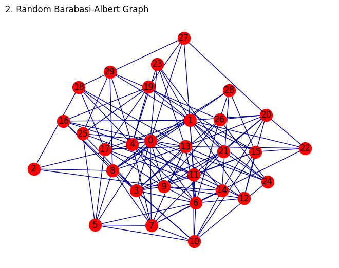

```python
import networkx as nx

# Create a barabasi-albert graph (G) with 30 nodes, grown by attaching new nodes each with
#  5 edges that are preferentially attached to existing nodes with high degree. (1pt)
n = 30
m = 5 # as stated

G_ba = nx.barabasi_albert_graph(n,m,seed=seed)

# Draw the graph (1pt)
nx.draw(G_ba, with_labels=True, node_color='red', edge_color='darkblue')
plt.title('2. Random Barabasi-Albert Graph', loc="left")
plt.show()
```

## **2. Compute diverse node-level features for a random barabasi-albert graph (16pts)**

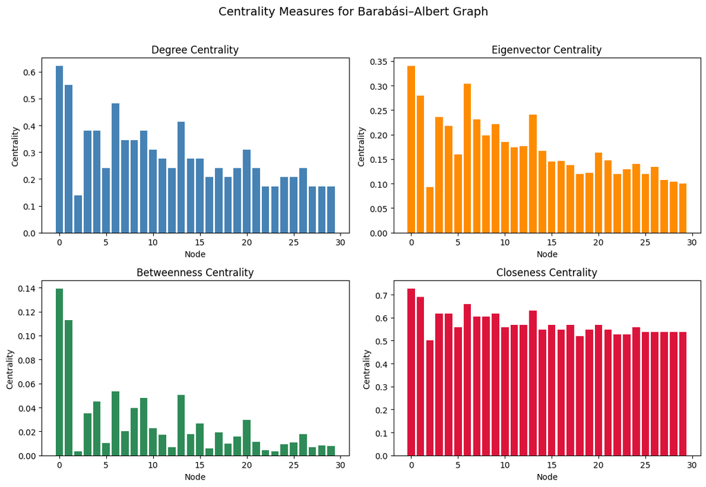

```
Top 3 nodes by  Degree Centrality
0 0.62
1 0.55
6 0.48


Top 3 nodes by  Eigenvector Centrality
0 0.34
6 0.3
1 0.28


Top 3 nodes by  Betweenness Centrality
0 0.14
1 0.11
6 0.05


Top 3 nodes by  Closeness Centrality
0 0.72
1 0.69
6 0.66
```

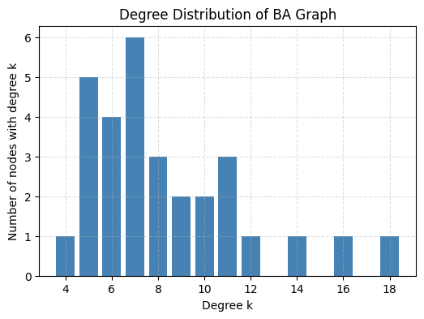

```python
# Compute centrality measures (degree, eigenvector, betweeness, closeness). (4pts)
C_d = nx.degree_centrality(G_ba)
C_e = nx.eigenvector_centrality(G_ba)
C_b = nx.betweenness_centrality(G_ba)
C_c = nx.closeness_centrality(G_ba)


# Plot the centrality measures with bar plots (x: node index, y: centrality values) into one figure with 2 rows and 2 columns. （2pts)
# Convert to lists ordered by node index
nodes = sorted(G_ba.nodes())
deg_vals  = [C_d[n] for n in nodes]
eig_vals  = [C_e[n] for n in nodes]
bet_vals  = [C_b[n] for n in nodes]
clos_vals = [C_c[n] for n in nodes]

# Create subplots
fig, axs = plt.subplots(2, 2, figsize=(12, 8))
fig.suptitle("Centrality Measures for Barabási–Albert Graph", fontsize=14, y=1.02)


# Visualize the graph with nodes colored by different centrality measures,
# i.e.,  plot 4 subplots (2 rows*2 columns) in one figure for 4 centrality measures. (2pts)

# Degree centrality
axs[0, 0].bar(nodes, deg_vals, color="steelblue")
axs[0, 0].set_title("Degree Centrality")
axs[0, 0].set_xlabel("Node")
axs[0, 0].set_ylabel("Centrality")

# Eigenvector centrality
axs[0, 1].bar(nodes, eig_vals, color="darkorange")
axs[0, 1].set_title("Eigenvector Centrality")
axs[0, 1].set_xlabel("Node")
axs[0, 1].set_ylabel("Centrality")

# Betweenness centrality
axs[1, 0].bar(nodes, bet_vals, color="seagreen")
axs[1, 0].set_title("Betweenness Centrality")
axs[1, 0].set_xlabel("Node")
axs[1, 0].set_ylabel("Centrality")

# Closeness centrality
axs[1, 1].bar(nodes, clos_vals, color="crimson")
axs[1, 1].set_title("Closeness Centrality")
axs[1, 1].set_xlabel("Node")
axs[1, 1].set_ylabel("Centrality")

plt.tight_layout()
plt.show()


# For each centrality measure, print the top three nodes along with their corresponding centrality values. (6pts)
def printTopThree(name, centrality_dict):
  sorted_dict = dict(sorted(centrality_dict.items(), key=lambda item: item[1], reverse=True))
  top_three = dict(list(sorted_dict.items())[:3])
  print("Top 3 nodes by ",name)
  for node, val in top_three.items():
    print(node, round(val,2))

printTopThree("Degree Centrality", C_d)
print("\n")
printTopThree("Eigenvector Centrality", C_e)
print("\n")
printTopThree("Betweenness Centrality", C_b)
print("\n")
printTopThree("Closeness Centrality", C_c)


# Check whether the created barabasi-albert graph follows a power-law distribution. (2pts)

'''
A power law distribution is a statistical relationship where one quantity varies as a constant power of another,
commonly expressed as y = ax^k, meaning that small events are frequent while large events are rare but can be
significantly more extreme than in a normal distribution. This "scale-free" distribution is characterized by a
"fat tail," allowing for extremely large outcomes, unlike the "thin tail" of a normal (bell curve) distribution.
It is defined by the size (by def. degree) of the nodes in the graph.
'''

deg = [d for _, d in G_ba.degree()]

# Count nodes for each degree
unique_deg, counts = np.unique(deg, return_counts=True)

# Plot degree distribution
plt.figure(figsize=(6,4))
plt.bar(unique_deg, counts, width=0.80, color="steelblue")

plt.xlabel("Degree k")
plt.ylabel("Number of nodes with degree k")
plt.title("Degree Distribution of BA Graph")
plt.grid(True, which="both", ls="--", alpha=0.4)
plt.show()
```

## **3. Spectral measures (e.g., Katz index and HITS) (12pts)**

```
All eigenvalues are  [0. 0. 0. 0. 0. 0. 0. 0. 0. 0. 0. 0. 0. 0. 0.]
Largest eigen value of DAG's adjacency matrix is 0.00
```

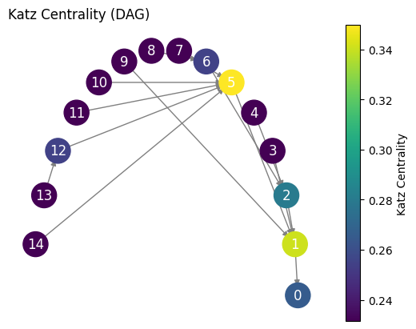

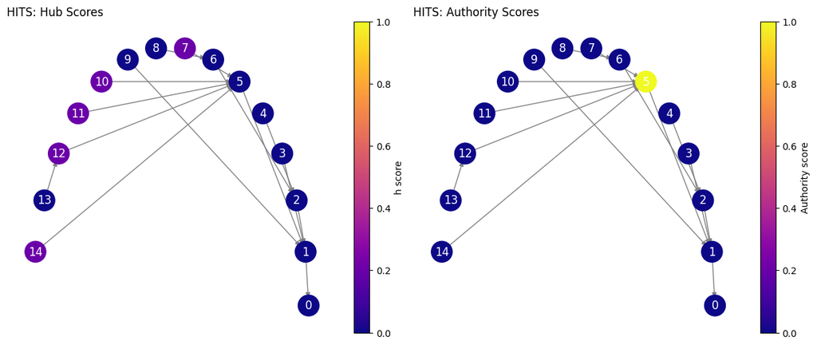

```
Top Hub nodes:
Node : 14 has an hub score of 0.20000000000000004
Node : 12 has an hub score of 0.20000000000000004
Node : 11 has an hub score of 0.20000000000000004
Node : 10 has an hub score of 0.20000000000000004
Node : 7 has an hub score of 0.20000000000000004
Top Authority nodes:
Node : 5 has an authority score of 1.0000000000000002
Node : 13 has an authority score of 5.551115123125784e-17
Node : 11 has an authority score of 5.551115123125784e-17
Node : 10 has an authority score of 2.775557561562892e-17
Node : 6 has an authority score of 2.775557561562892e-17
```

```python
# Create a directed acyclic graph (DAG).
import networkx as nx
import pandas as pd

# Create a directed acyclic graph. (DAG)
DAG = nx.gn_graph(15, seed=33)

# Compute Katz centrality for DAG. (2pts)
A = nx.adjacency_matrix(DAG).todense()

eigenValues = np.linalg.eigvals(A)
print("All eigenvalues are ",eigenValues)
largestLambda = max(abs(eigenValues))
print(f"Largest eigen value of DAG's adjacency matrix is {largestLambda:.2f}")

'''
A of DAG's is always nilpotent.
Since largestLambda is 0, 1/largestLambda will be tending to infinity. We can take any integer for alpha.
'''
# using default value of 0.1 for alpha and 1 for beta with 1000 iterations.
kc = nx.katz_centrality_numpy(DAG)


# Visualize nodes colored by Katz centrality (DAG). (2pts)

# Extract values in node order
values = [kc[node] for node in DAG.nodes()]

# Layout
pos = nx.circular_layout(G)

# Draw the graph
nodes = nx.draw_networkx_nodes(DAG,pos, node_color=values, cmap=plt.cm.viridis, node_size=500)
nx.draw_networkx_edges(DAG, pos, arrows=True, edge_color="gray")
nx.draw_networkx_labels(DAG, pos, font_color="white")

# Add colorbar
plt.colorbar(nodes, label="Katz Centrality")
plt.title("Katz Centrality (DAG)", loc="left")
plt.axis("off")
plt.show()


# Compute HITS centrality for DAG. (2pts)
h, a = nx.hits(DAG,max_iter=1000)

# Visualize nodes colored by HITS hub and authority scores, respectively (one figure with 1*2 subplots). (2pts)

# Extract scores in consistent order
nodes = list(DAG.nodes())
h_vals  = np.array([h[n] for n in nodes])
a_vals = np.array([a[n] for n in nodes])

# Shared color scale for consistency
vmin = min(h_vals.min(), a_vals.min())
vmax = max(h_vals.max(), a_vals.max())

# Shared color scale for consistency
vmin = min(h_vals.min(), a_vals.min())
vmax = max(h_vals.max(), a_vals.max())

fig, axes = plt.subplots(1, 2, figsize=(12, 5), constrained_layout=True)

# hubs
ax = axes[0]
ncoll = nx.draw_networkx_nodes(DAG, pos, ax=ax, node_color=h_vals, cmap="plasma", vmin=vmin, vmax=vmax, node_size=500)
nx.draw_networkx_edges(DAG, pos, ax=ax, arrows=True, edge_color="gray")
nx.draw_networkx_labels(DAG, pos, ax=ax, font_color="white")
fig.colorbar(ncoll, ax=ax, label="h score")
ax.set_title("HITS: Hub Scores", loc="left")
ax.axis("off")

# authorities
ax = axes[1]
ncola = nx.draw_networkx_nodes(DAG, pos, ax=ax, node_color=a_vals, cmap="plasma", vmin=vmin, vmax=vmax, node_size=500)
nx.draw_networkx_edges(DAG, pos, ax=ax, arrows=True, edge_color="gray")
nx.draw_networkx_labels(DAG, pos, ax=ax, font_color="white")
fig.colorbar(ncola, ax=ax, label="Authority score")
ax.set_title("HITS: Authority Scores", loc="left")
ax.axis("off")

plt.show()

# Find top hubs and authority nodes and provide your own explanation of why these nodes rank highly and what roles they play within the network. (4pts)
top_hubsIndices = np.argsort(h_vals)[::-1][:5]
print("Top Hub nodes:")
for index in top_hubsIndices:
  print(f"Node : {nodes[index]} has an hub score of {h_vals[index]}")

top_authsIndices = np.argsort(a_vals)[::-1][:5]
print("Top Authority nodes:")
for index in top_authsIndices:
  print(f"Node : {nodes[index]} has an authority score of {a_vals[index]}")
```

#### Explanation for hub and authority scores in HITS.

- A node is a strong hub if it points to strong authority nodes, which is visible in the graph as nodes 14, 12, 11 and 10 point directly to the strong authority node 5. These nodes channel the influence towards node 5. The hubs reinforce the centrality and importance of node 5 by serving as distributors or sources of information.
- A node has a strong authority if it pointed to by many strong hubs. In graph, clearly 5 is the strong authority. Other nodes such as 2 and 1 are pointed to by weaker hubs. The high authority score for 5 also backs the fact it is clearly the endpoint of many directed paths in this DAG. It also indicates that that it is the central connector, serving as the bottleneck and a point of vulnerability. As it is a trusted reference for many hubs, it is vital for aggregating or validating information.
- If hubs represent influential people, authorities can be considered to be very credible people as they can serve as information validators.